# Assignment1_KVDF

Valerie de la Fuente

4/9/2018

# Part 1 Visualization critique

I’m going to criticize the first graph of the following article:

https://projects.fivethirtyeight.com/jobs-report-growth-unemployment/

One of the main features of this graph is its truthfulness, the graph???s main purpose is to scrutinize jobs data by comparing it to past figures and by considering the fact that the numbers given are constantly revised and adjusted. In this sense, the graph does a good job showing the upward and downward revisions of the data. Additionally, both y and x axis make sense as well.

The truthfulness and functionality of this graph may overlap because its main purpose is to be truthful. The graph achieves it by using color to depict the constant revisions of data. Nevertheless, a better balance between detail and readability could have been achieved by making two graphs to show the different trends more clearly.

The designer did a good job incorporating the interactive effects so that the graph doesn???t look full of text and looks ???clean???, which makes it look beautiful. Their use of shapes and color is good, however, they could have chosen other colors that contrast better. However, the year labels could be placed before January starts so that it is less confusing.

In terms of insightfulness, the graph achieves it because it is knowledge building. The viewer can learn about the upward and downward revision trends, get a good sense of historical data and follow the story in an interactive way.

The graph is also enlightening, job rates and growth is a fundamental macro economic indicator and the analysis shown by the graph, makes it easier to judge alleged improvements or losses. The data depicted in this graph is important because, by understanding better these trends, the population becomes more aware of when the media is exaggerating job creation or downplaying it to criticize or support a party.

# Part 2: ggplot2 and the grammar of graphics

```r
library(tidyverse)
gss_cat %>%
  count(marital)
```

```
## # A tibble: 6 x 2
##   marital           n
##   <fctr>        <int>
## 1 No answer        17
## 2 Never married  5416
## 3 Separated       743
## 4 Divorced       3383
## 5 Widowed        1807
## 6 Married       10117
```

```r
gss_cat1 <-
gss_cat[gss_cat$marital !="No answer", , drop = FALSE]; gss_cat$marital <- factor(gss_cat$marital)
```

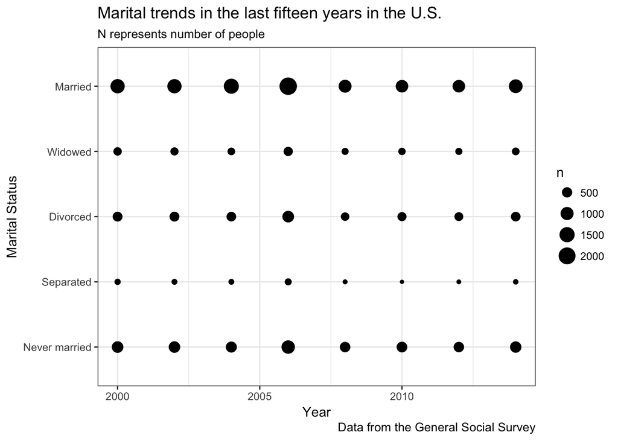

```r
gss_cat1 %>%
  filter(age > 16) %>%
  ggplot(mapping = aes(x = year , y = marital)) +
  geom_count() +
  labs(title = "Marital trends in the last fifteen years in the U.S.",
       subtitle = "N represents number of people",
       caption = "Data from the General Social Survey",
       x = "Year", y = "Marital Status") +
  theme(legend.position = "bottom") +
  theme_bw()
```

Sources: https://stackoverflow.com/questions/3813190/removing-a-particular-category-from-a-data-frame-in-r

http://r4ds.had.co.nz/

I think the graph is beautiful because it is simple. It doesn???t use more color because we didn???t include additional categories. I defined the x axis as year, so that it is easier to read as a passage of time, and the y axis has clearly defined categories. I also used a white background to contrast better with black.

It is insightful because it builds knowledge on how is the American Society distributed among marital status and how that distribution hasn???t changed much in 15 years in spite of articles talking about millenials choices to not marry or other similar factors. The graph is straightforward and simple for any person to understand it.

The graph is enlightening because it addresses an important demographic category that has a correlation with income, education trends and the evolution of women in the workplace. According to this graph, in spite of recent trends, marital status choice hasn???t changed much.